# Ambient-noise models for gRNA guide assignment: fishash, fishash+, and CLEANSER

A cross-dataset comparison of how three methods estimate ambient depth and separate signal from soup

Author

sceptre3 guide-assignment working group

Published

July 5, 2026

# 1 Overview

Guide assignment in single-cell CRISPR screens is the problem of deciding, for every (guide, cell) pair, whether the observed UMI count reflects a **real integration** or **ambient contamination** (“soup”). Every method here tests the same thing — is the count larger than we’d expect from ambient noise? — and the ambient rate is modeled as a rank-1 field, $\lambda_{g,c} = a_g\, d_c$, the product of a **guide’s** soup share $a_g$ and a **cell’s** ambient depth $d_c$. The three methods differ almost entirely in **how they estimate the cell’s ambient depth $d_c$**:

| method | cell ambient depth $d_c$ | one-line description |
| --- | --- | --- |
| **fishash** | the cell’s **raw library size** $N_{:,c}$ | noise-conditioned hypergeometric test; decontaminates the *guide* margin (Simpson correction) but uses the raw library as the cell’s exposure |
| **fishash+** | the **denoised rank-1** cell factor (soup only) | fishash’s test with the cell margin also decontaminated — the “depth_fix” — so co-occurring real guides don’t inflate a cell’s exposure |
| **CLEANSER** | the sum of that cell’s **≤2-count** UMIs | per-guide Bayesian NB mixture; its cell size factor is built from sub-threshold (presumed signal-free) guides |

The distinction matters most at **high MOI / high sequencing depth**, where a cell carries many guides and the raw library size is dominated by real signal. This document compares the three on every real dataset we have, along three axes: **(i)** the per-cell ambient depth $d_c$ each infers, **(ii)** how many cells each leaves as ambient at each gRNA count, and **(iii)** how much their assignments agree. *(Downstream association testing — plugging each assignment into SCEPTRE — is a separate analysis and is not included here.)*

Real datasets analyzed (ordered by median gRNA library size). ‘CLEANSER assignments’ = whether the MCMC assignment finished; CLEANSER’s ≤2 depth estimate is available for all.

| dataset | guides | cells | median library | CLEANSER assignments |
| --- | --- | --- | --- | --- |
| dctap_k562_highmoi | 110 | 10932 | 1860 | yes |
| barnyard_mch2_72hr | 200 | 8057 | 1664 | yes |
| replogle-rd7 | 2666 | 616184 | 1178 | depth only |
| gasperini | 13077 | 207324 | 564 | depth only |
| barnyard_mch2_0hr | 200 | 8902 | 516 | yes |
| endoc_t2d | 225 | 8329 | 441 | yes |
| a549 | 253 | 25220 | 399 | yes |
| dctap_k562_lowmoi | 110 | 5397 | 354 | yes |
| ipsc | 6824 | 322746 | 282 | depth only |
| invivo_cortex | 17 | 11688 | 259 | yes |
| barnyard_lrb100_0hr | 200 | 7453 | 63 | yes |
| gastric_organoid | 96 | 42324 | 63 | yes |
| barnyard_lrb100_72hr | 200 | 8793 | 56 | yes |
| cd4_tcell | 27272 | 137716 | 33 | depth only |
| erythroid_multiome | 63 | 14525 | 28 | yes |
| mccutcheon | 40 | 22100 | 8 | yes |
| cd8_tcell | 44 | 2426 | 5 | yes |

# 2 Per-cell ambient depth

The core quantity each method needs is the cell’s ambient depth $d_c$ — the exposure a count is tested against. Critically, this is the depth each method **actually uses**, which is not the same across methods: **fishash uses the raw library size** $N_{:,c}$ (it computes a rank-1 field, but only for the guide-margin Simpson correction — the cell exposure it tests against is the raw library); **fishash+ uses the denoised rank-1 depth** $\hat d_c$; **CLEANSER uses $L_i$, the sum of the cell’s ≤2 counts**. These three can differ by orders of magnitude.

## 2.1 Distributions of depth used

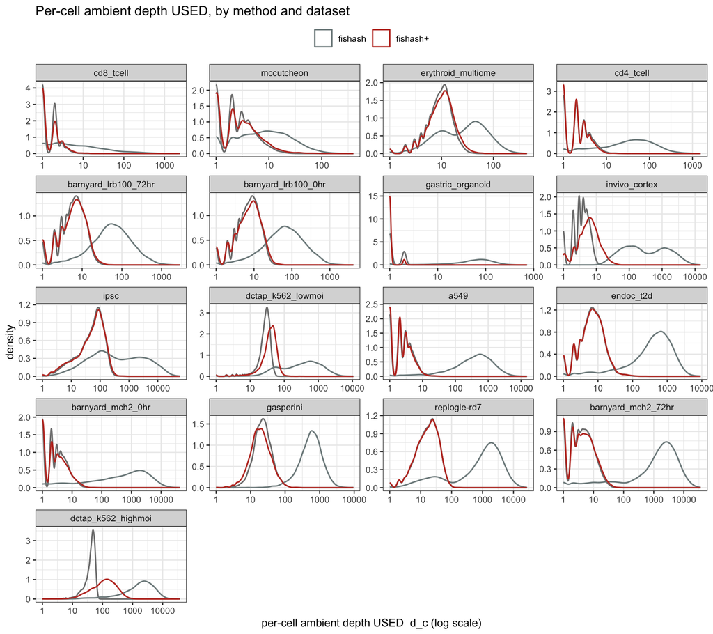

**fishash’s raw-library depth (grey) is inflated far above the other two** — often 5–400× (e.g. barnyard_mch2_72hr median 1664 vs ~4; DC-TAP high-MOI 1860 vs 116 vs 43) — because the raw library is dominated by the cell’s own real integrations, exactly the signal a cell-margin should *exclude*. fishash+ (rank-1) and CLEANSER (≤2) are much closer to each other and to the true ambient scale; they pull apart only in the **deep direct-capture** datasets, where CLEANSER’s ≤2 cap discards genuine ambient UMIs (rank-1 > ≤2).

## 2.2 fishash+ (rank-1) vs CLEANSER (≤2) depth

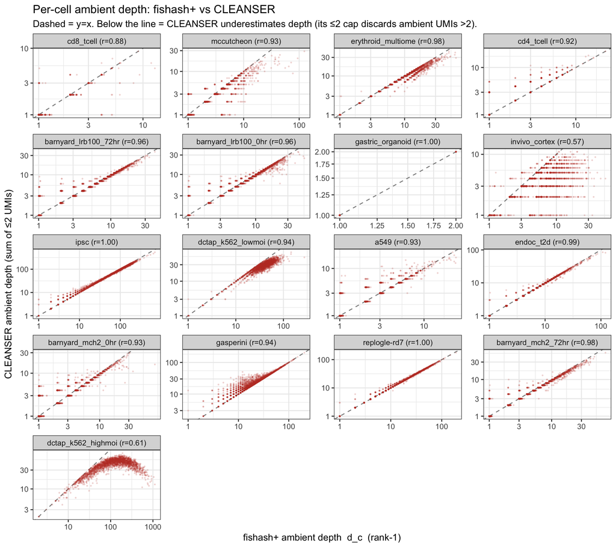

| dataset | fishash (raw lib) | fishash+ (rank-1) | CLEANSER (≤2) | spearman(f+ , CLEANSER) |
| --- | --- | --- | --- | --- |
| dctap_k562_highmoi | 1860 | 115.8 | 43 | 0.470 |
| barnyard_mch2_72hr | 1664 | 4.1 | 4 | 0.971 |
| replogle-rd7 | 1178 | 17.0 | 18 | 0.998 |
| gasperini | 564 | 19.0 | 22 | 0.935 |
| barnyard_mch2_0hr | 516 | 3.0 | 3 | 0.914 |
| endoc_t2d | 441 | 7.1 | 7 | 0.994 |
| a549 | 399 | 2.1 | 3 | 0.921 |
| dctap_k562_lowmoi | 354 | 39.5 | 29 | 0.870 |
| ipsc | 282 | 60.1 | 60 | 0.999 |
| invivo_cortex | 259 | 6.0 | 4 | 0.547 |
| barnyard_lrb100_0hr | 63 | 7.5 | 8 | 0.980 |
| gastric_organoid | 63 | 1.0 | 1 | 1.000 |
| barnyard_lrb100_72hr | 56 | 6.2 | 6 | 0.981 |
| cd4_tcell | 33 | 2.0 | 2 | 0.899 |
| erythroid_multiome | 28 | 10.1 | 10 | 0.973 |
| mccutcheon | 8 | 2.3 | 2 | 0.917 |
| cd8_tcell | 5 | 1.1 | 1 | 0.862 |

# 3 Ambient cells at each gRNA count

A second view: at each gRNA UMI count $k$, what fraction of the (guide, cell) observations does each method leave as **ambient** (unassigned)? At $k=1$–2 essentially everything is ambient; as $k$ grows, real integrations appear and the ambient fraction should fall. The methods differ sharply in *where* it falls:

- **fishash** keeps a long ambient tail — in deep cells its inflated exposure leaves even large counts unassigned (self-masking).
- **fishash+** cuts the ambient fraction to ~0 much sooner.
- **CLEANSER**, by construction, treats counts ≤2 as ambient and >2 as candidate signal — effectively a step at $k=2$ (shown as a dashed reference; where the MCMC assignment is available, its empirical curve is drawn too).

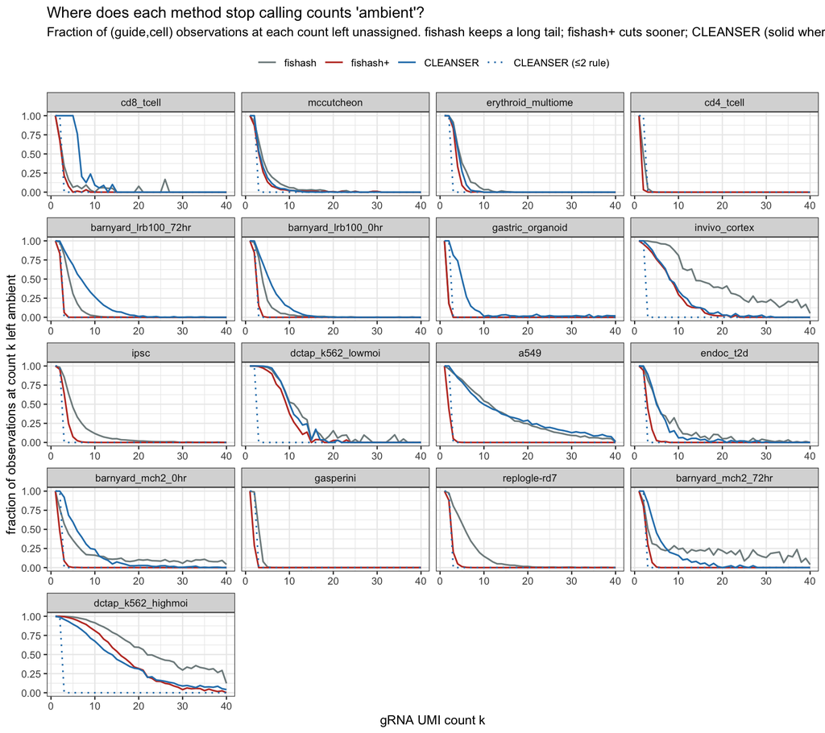

## 3.1 Per-guide ambient ceiling: fishash vs fishash+

The **ambient ceiling** of a guide is the largest count a method still leaves unassigned. fishash’s ceilings run into the hundreds/thousands on deep data (it fails to assign genuine strong integrations); fishash+’s are far lower.

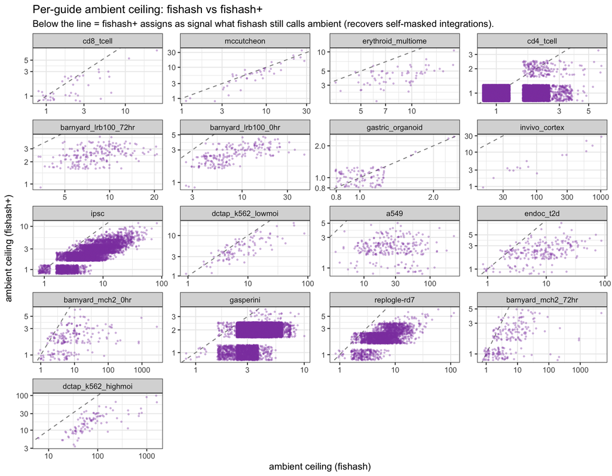

# 4 Per-guide view: which counts each method calls ambient

Zooming into individual guides makes the differences concrete. Using the DC-TAP positive-control guides (targeting GATA1, HDAC6, MYC), we plot the observed gRNA-count histogram (grey bars) and, for each count bin, the **number of those cells each method leaves ambient** (unassigned). Where a line rides along the top of the bars, the method is calling that count ambient; where it drops below the bars, it is assigning those cells as real signal.

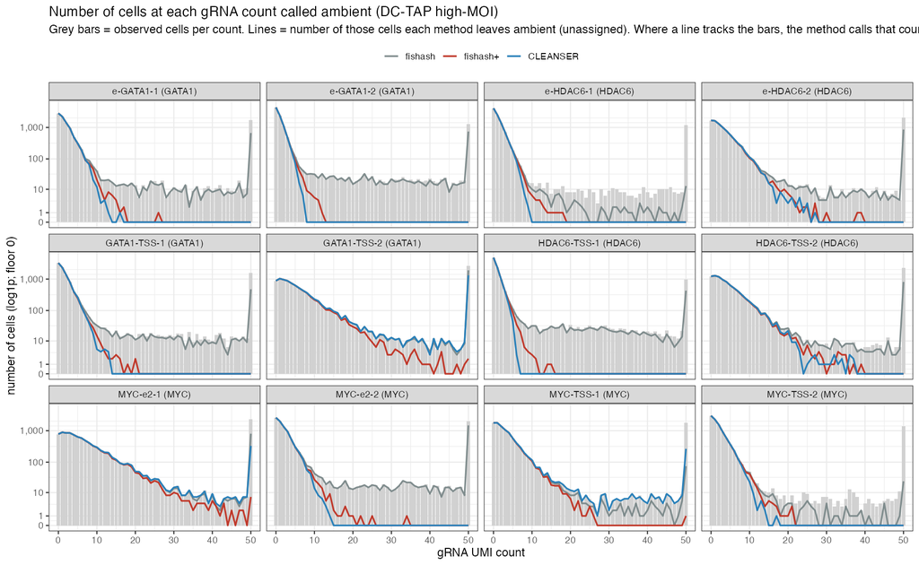

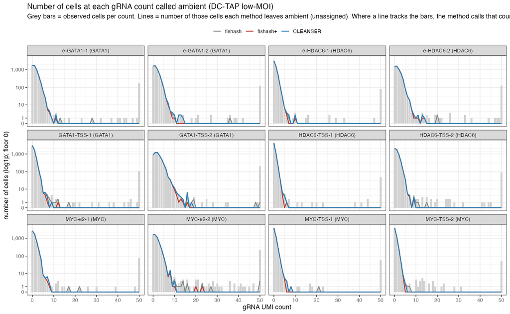

DC-TAP **low-MOI**. With cells carrying ~one guide, the three methods largely agree — all of them pull away from the bars at moderate counts, so far fewer high-count cells are left ambient. The divergence above is a high-MOI/high-depth phenomenon.

At **high MOI** the three separate cleanly:

At **low MOI** the three largely coincide: with roughly one guide per cell there is little co-occurring signal to inflate a cell’s depth, so all three assign the high-count cells.

# 5 Assignment agreement

How much do the three methods actually agree on which (guide, cell) pairs are real? We measure the **Jaccard similarity** of their assigned-entry sets.

## 5.1 fishash vs fishash+ (all datasets)

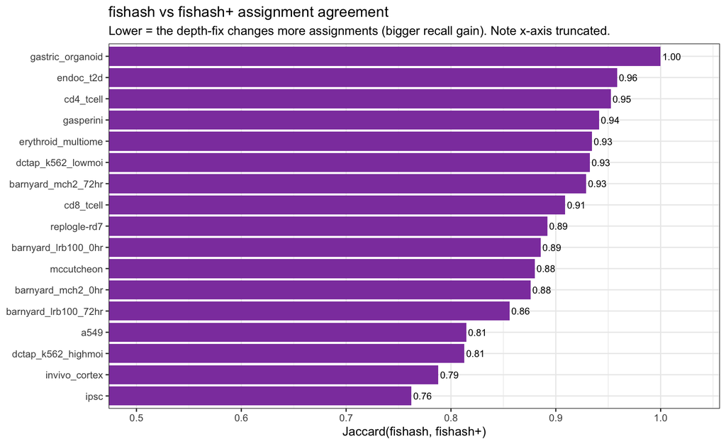

## 5.2 Three-way agreement (datasets with CLEANSER assignments)

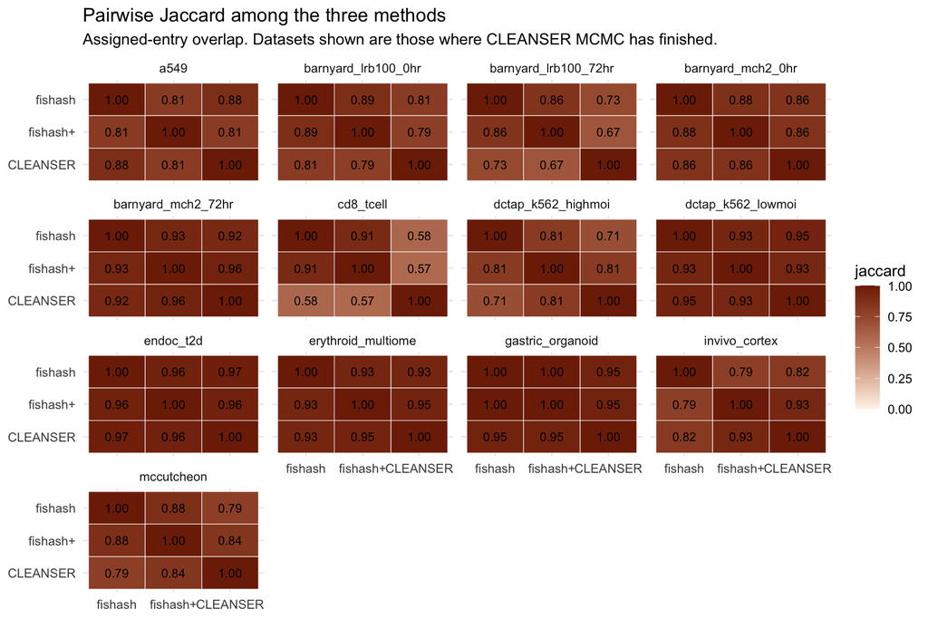

## 5.3 Who assigns what the others don’t?

Among (guide, cell) pairs assigned by **at least one** method, how many are agreed on by all three, and how many are unique to a single method? A method whose “unique” calls are real integrations is adding recall; one whose unique calls are noise is over-assigning.

Fraction of the union of assigned entries falling in each agreement class. ‘f+ & CLNS, not fishash’ = the self-masked integrations both cell-margin-decontaminated methods recover but fishash misses.

|  | dataset | union entries | all 3 | fishash only | fishash+ only | CLEANSER only | f+ & CLNS, not fishash |
| --- | --- | --- | --- | --- | --- | --- | --- |
| a549 | a549 | 117833 | 0.762 | 0.001 | 0.137 | 0.000 | 0.048 |
| barnyard_lrb100_0hr | barnyard_lrb100_0hr | 43433 | 0.748 | 0.000 | 0.074 | 0.000 | 0.041 |
| barnyard_lrb100_72hr | barnyard_lrb100_72hr | 52208 | 0.645 | 0.000 | 0.115 | 0.000 | 0.029 |
| barnyard_mch2_0hr | barnyard_mch2_0hr | 39387 | 0.802 | 0.001 | 0.062 | 0.000 | 0.060 |
| barnyard_mch2_72hr | barnyard_mch2_72hr | 30928 | 0.901 | 0.001 | 0.017 | 0.000 | 0.053 |
| cd8_tcell | cd8_tcell | 1142 | 0.548 | 0.020 | 0.059 | 0.000 | 0.012 |
| dctap_k562_highmoi | dctap_k562_highmoi | 133937 | 0.683 | 0.000 | 0.034 | 0.130 | 0.128 |
| dctap_k562_lowmoi | dctap_k562_lowmoi | 6379 | 0.904 | 0.000 | 0.045 | 0.001 | 0.022 |
| endoc_t2d | endoc_t2d | 23782 | 0.946 | 0.000 | 0.026 | 0.000 | 0.016 |
| erythroid_multiome | erythroid_multiome | 18039 | 0.911 | 0.000 | 0.025 | 0.007 | 0.039 |
| gastric_organoid | gastric_organoid | 40806 | 0.952 | 0.000 | 0.000 | 0.000 | 0.000 |
| invivo_cortex | invivo_cortex | 16533 | 0.775 | 0.000 | 0.058 | 0.014 | 0.151 |
| mccutcheon | mccutcheon | 19968 | 0.762 | 0.000 | 0.035 | 0.039 | 0.079 |